# NYC Summer 2019 Bike Share Use

Steve Buyske

Notice that this is an [R Markdown](http://rmarkdown.rstudio.com) Notebook. When you execute code within the notebook, the results appear beneath the code.

You can execute chunks by clicking the *Run* button within the chunk or by placing your cursor inside it and pressing *Cmd+Shift+Enter* on a Mac or *Control+Shift+Enter* on Windows. You can go line by line with *Cmd+Enter* on a Mac or *Control+Enter* on Windows.

## Data

We will look at daily bike rentals from citibike, a bike share program in New York City, over the summer of 2019 and the summer of 2020.

```r
citibike <- read_csv("citibike.csv")
# Data aggregated from https://www.citibikenyc.com/system-data

# the code below will make sure that the days of the week go in order rather than alphabetically,
# and that year is treated not as a number but as a categorical variable
citibike <- citibike %>%
  mutate(day_of_the_week = factor(day_of_the_week, levels = c("Mon", "Tue", "Wed", "Thu", "Fri", "Sat", "Sun")),
         year = factor(year))

# A dataset with only 2019 data and one with only 2020 data

citibike2019 <- citibike %>%
  filter(year == "2019")

citibike2020 <- citibike %>%
  filter(year == "2020")

citibike %>% glimpse()
```

```
Rows: 184
Columns: 5
$ date            <date> 2019-06-01, 2019-06-02, 2019-06-03, 2019-06-04, 2019-0…
$ day             <dbl> 152, 153, 154, 155, 156, 157, 158, 159, 160, 161, 162, …
$ year            <fct> 2019, 2019, 2019, 2019, 2019, 2019, 2019, 2019, 2019, 2…
$ day_of_the_week <fct> Sat, Sun, Mon, Tue, Wed, Thu, Fri, Sat, Sun, Mon, Tue, …
$ rides           <dbl> 1350, 1109, 1371, 1604, 1413, 1481, 1547, 1209, 1338, 8…
```

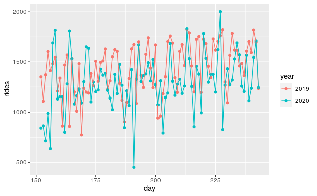

```r
citibike %>%
  ggplot(aes(day, rides, colour = year)) +
  geom_point() +
  geom_line()
```

From the plot, it looks like there might be a trend during the week, a linear increase during the summer, and lower use in 2020.

## 2019 model fit

I want to start by looking at 2019 only. We will include a `day` variable, which is day of the year, and also separate intercepts for the day of the week, using a hierarchical model. The argument `control = list(adapt_delta = 0.999)` is something to fix a problem that we won’t discuss for a few weeks.

```r
citi_hier_2019 <- stan_glmer(rides ~ day + (1 | day_of_the_week), data = citibike2019, control = list(adapt_delta = 0.999))
```

```
There were 1 divergent transitions after warmup. See
http://mc-stan.org/misc/warnings.html#divergent-transitions-after-warmup
to find out why this is a problem and how to eliminate them.Examine the pairs() plot to diagnose sampling problems
```

Did this run long enough? We can use the `stableGR` approach. I’ll pick `day` as a parameter just to focus on something.

```r
citi_hier_2019 %>%
  as.array(pars = "day") %>%
  as.matrix %>%
  n.eff()
```

```
$n.eff
      se
4608.518

$converged
[1] FALSE

$n.target
  se
5335
```

Apparently not, since `converged` is `FALSE`. Let’s just go with 5000 iterations per chain. Notice the `cores = 4` argument to run the chains in parallel on the computer, which should be a little faster.

```r
citi_hier_2019 <- stan_glmer(rides ~ day + (1 | day_of_the_week), data = citibike2019, iter = 5000, control = list(adapt_delta = 0.999), cores = 4)
```

```
starting worker pid=3854 on localhost:11477 at 01:50:02.516
starting worker pid=3868 on localhost:11477 at 01:50:02.694
starting worker pid=3882 on localhost:11477 at 01:50:02.871
starting worker pid=3896 on localhost:11477 at 01:50:03.050
```

```r
citi_hier_2019 %>%
  as.array(pars = "day") %>%
  as.matrix %>%
  n.eff()
```

```
$n.eff
      se
9658.206

$converged
[1] TRUE

$n.target
NULL
```

Looks good. Looking at `shinystan` doesn’t raise any other convergence concerns. Remember to close the `shinystan` window when you are done.

```r
launch_shinystan(citi_hier_2019)
```

[output not shown]

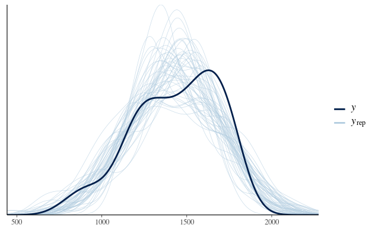

```r
pp_check(citi_hier_2019)
```

## Look at results

Let’s take a look at the distribution of the day of the week specific changes in the intercept. The `regex_pars = "Intercept.+day.of.the.week"` argument below is a pattern designed to pick out just the parameters we want—we’ll talk about it just a little later this semester. If you’re curious, `.` represents any character, and `.+` represents one or more of any character.

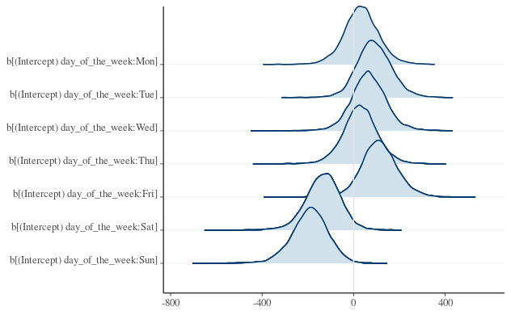

```r
plot(citi_hier_2019, plotfun = "areas_ridges", regex_pars = "Intercept.+day.of.the.week")
```

Pretty clearly Saturday and Sunday show a shift towards fewer rides, while Friday is a bit higher than the other weekdays.

Let’s take a quick look at the numeric results. I want to use an interval of $(-50, 50)$ for the ROPE. Notice in the code it is written as `c(-50, 50)`.

```r
model_parameters(citi_hier_2019, ci = 0.9, rope_ci = 0.9, rope_range = c(-50, 50))
```

```
# Fixed effects

Parameter   | Median |           90% CI |     pd | % in ROPE |  Rhat |     ESS |                      Prior
-----------------------------------------------------------------------------------------------------------
(Intercept) | 705.13 | [425.83, 986.96] | 99.97% |        0% | 1.000 | 6723.37 | Normal (1433.55 +- 634.96)
day         |   3.69 | [  2.39,   5.02] |   100% |      100% | 1.000 | 9230.32 |     Normal (0.00 +- 23.78)
```

We can see the group effect by adding the argument `effects = "random"` to the function call.

```r
model_parameters(citi_hier_2019, ci = 0.9, rope_ci = 0.9, rope_range = c(-50, 50), effects = "random")
```

```
# Fixed effects

Parameter   | Median | 90% CI | pd | % in ROPE | Rhat | ESS |                      Prior
----------------------------------------------------------------------------------------
(Intercept) |        |        |    |           |      |     | Normal (1433.55 +- 634.96)
day         |        |        |    |           |      |     |     Normal (0.00 +- 23.78)

# Random effects Intercept: day_of_the_week

Parameter           |  Median |            90% CI |     pd | % in ROPE |  Rhat |     ESS |     Prior
----------------------------------------------------------------------------------------------------
day_of_the_week:Mon |   33.21 | [ -87.33, 163.08] | 68.06% |    52.13% | 1.000 | 3536.66 | NA ( +- )
day_of_the_week:Tue |   88.11 | [ -29.27, 215.12] | 89.51% |    27.30% | 1.000 | 4014.78 | NA ( +- )
day_of_the_week:Wed |   65.55 | [ -58.58, 187.90] | 82.81% |    39.45% | 1.000 | 3584.45 | NA ( +- )
day_of_the_week:Thu |   28.80 | [ -98.62, 149.70] | 66.18% |    53.24% | 1.000 | 3531.60 | NA ( +- )
day_of_the_week:Fri |  111.39 | [  -9.58, 241.49] | 93.70% |    16.35% | 1.000 | 3687.21 | NA ( +- )
day_of_the_week:Sat | -131.40 | [-252.88,  -9.52] | 96.71% |     8.90% | 1.000 | 3615.37 | NA ( +- )
day_of_the_week:Sun | -188.57 | [-317.62, -59.72] | 99.45% |        0% | 1.001 | 3759.27 | NA ( +- )

# Random effects SD/Cor: day_of_the_week

Parameter   |   Median |              90% CI |   pd | % in ROPE |  Rhat |     ESS |     Prior
---------------------------------------------------------------------------------------------
(Intercept) | 18467.94 | [3070.42, 48951.78] | 100% |        0% | 1.001 | 3302.53 | NA ( +- )
```

You can see that from the `pd` column that we are most confident that Saturday and Sunday are to one side of zero. Notice also that the effect is negative—fewer riders—while in the Bay Area we saw last there were more on the weekend. You can see that only for Sunday would the ROP + HDI decision lead to “reject,” while all the others would be “undecided.”

## A direct probability calculation

It will help to know the names of the parameters that R is using. One way to do that is by using the `names()` function.

```r
citi_hier_2019 %>%
  as.data.frame() %>%
  names()
```

```
 [1] "(Intercept)"                                    "day"
 [3] "b[(Intercept) day_of_the_week:Mon]"             "b[(Intercept) day_of_the_week:Tue]"
 [5] "b[(Intercept) day_of_the_week:Wed]"             "b[(Intercept) day_of_the_week:Thu]"
 [7] "b[(Intercept) day_of_the_week:Fri]"             "b[(Intercept) day_of_the_week:Sat]"
 [9] "b[(Intercept) day_of_the_week:Sun]"             "sigma"
[11] "Sigma[day_of_the_week:(Intercept),(Intercept)]"
```

What is the probability that summer Sundays in 2019 had fewer rides than Mondays? We need to be able to write out the condition, and because the names are not legal R variable names we have to use back ticks.

```r
citi_hier_2019 %>%
  as.data.frame() %$%
  mean(`b[(Intercept) day_of_the_week:Sun]` < `b[(Intercept) day_of_the_week:Mon]`)
```

```
[1] 0.9984
```

It may take a while to get the syntax right, but once you are used to it the calculations are surprisingly quick to do.